# Chapter 6 Exercise Solutions

## Book Problem 6.5: Soft Drinks

1. Set up x and s control charts on this process. Does the process exhibit statistical control?
2. Set up an R chart, and compare with the s chart in part (a)
3. Remove the last observations in each of the last 5 samples and set up x and s control charts on this process

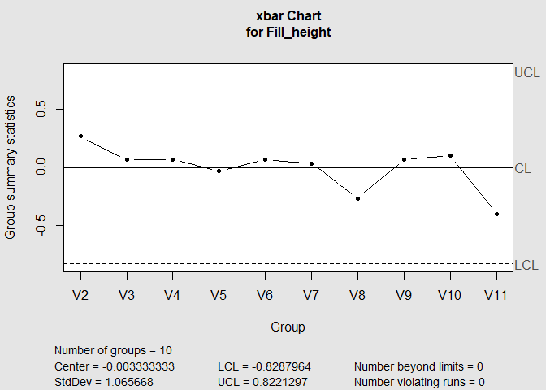

```
## List of 11
##  $ call      : language qcc(data = Fill_height, type = "xbar")
##  $ type      : chr "xbar"
##  $ data.name : chr "Fill_height"
##  $ data      : num [1:10, 1:15] 2.5 0.5 2 -1 1 -1 0.5 1.5 0.5 -1.5 ...
##   ..- attr(*, "dimnames")=List of 2
##  $ statistics: Named num [1:10] 0.2667 0.0667 0.0667 -0.0333 0.0667 ...
##   ..- attr(*, "names")= chr [1:10] "V2" "V3" "V4" "V5" ...
##  $ sizes     : Named int [1:10] 15 15 15 15 15 15 15 15 15 15
##   ..- attr(*, "names")= chr [1:10] "V2" "V3" "V4" "V5" ...
##  $ center    : num -0.00333
##  $ std.dev   : num 1.07
##  $ nsigmas   : num 3
##  $ limits    : num [1, 1:2] -0.829 0.822
##   ..- attr(*, "dimnames")=List of 2
##  $ violations:List of 2
##  - attr(*, "class")= chr "qcc"
```

```r
#a
library(qcc)
#see the Manual Data Entry Tutorial for instructions on getting the data to a csv format
Fill_height <- read.csv("Fill_height.csv") #read.csv reads a csv file into R
Fill_height <- as.data.frame(t(Fill_height)) #the data needs to be flipped using the t() function, which transposes matrices and dataframes. We then turn that transpose into a dataframe with the as.data.frame function

qcc(data = Fill_height, type = "xbar")
```

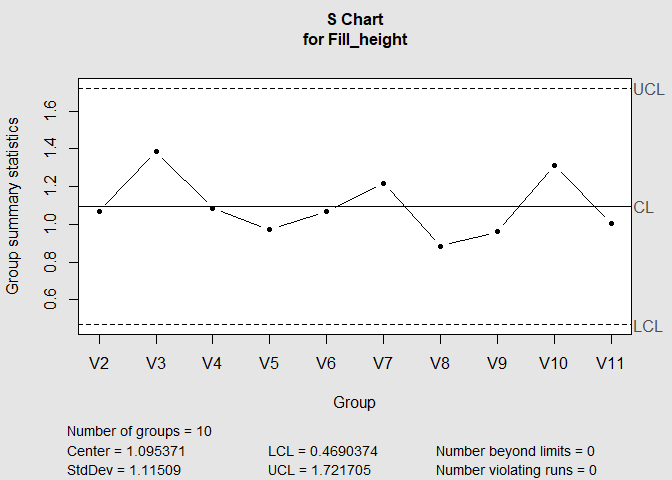

```
## List of 11
##  $ call      : language qcc(data = Fill_height, type = "S")
##  $ type      : chr "S"
##  $ data.name : chr "Fill_height"
##  $ data      : num [1:10, 1:15] 2.5 0.5 2 -1 1 -1 0.5 1.5 0.5 -1.5 ...
##   ..- attr(*, "dimnames")=List of 2
##  $ statistics: Named num [1:10] 1.067 1.387 1.083 0.972 1.067 ...
##   ..- attr(*, "names")= chr [1:10] "V2" "V3" "V4" "V5" ...
##  $ sizes     : Named int [1:10] 15 15 15 15 15 15 15 15 15 15
##   ..- attr(*, "names")= chr [1:10] "V2" "V3" "V4" "V5" ...
##  $ center    : num 1.1
##  $ std.dev   : num 1.12
##  $ nsigmas   : num 3
##  $ limits    : num [1, 1:2] 0.469 1.722
##   ..- attr(*, "dimnames")=List of 2
##  $ violations:List of 2
##  - attr(*, "class")= chr "qcc"
```

```r
qcc(data = Fill_height, type = "S")
```

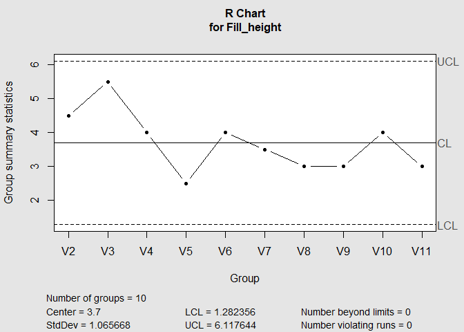

```
## List of 11
##  $ call      : language qcc(data = Fill_height, type = "R")
##  $ type      : chr "R"
##  $ data.name : chr "Fill_height"
##  $ data      : num [1:10, 1:15] 2.5 0.5 2 -1 1 -1 0.5 1.5 0.5 -1.5 ...
##   ..- attr(*, "dimnames")=List of 2
##  $ statistics: Named num [1:10] 4.5 5.5 4 2.5 4 3.5 3 3 4 3
##   ..- attr(*, "names")= chr [1:10] "V2" "V3" "V4" "V5" ...
##  $ sizes     : Named int [1:10] 15 15 15 15 15 15 15 15 15 15
##   ..- attr(*, "names")= chr [1:10] "V2" "V3" "V4" "V5" ...
##  $ center    : num 3.7
##  $ std.dev   : num 1.07
##  $ nsigmas   : num 3
##  $ limits    : num [1, 1:2] 1.28 6.12
##   ..- attr(*, "dimnames")=List of 2
##  $ violations:List of 2
##  - attr(*, "class")= chr "qcc"
```

```r
#b
#create an R chart using the qcc function
qcc(data = Fill_height, type = "R")
```

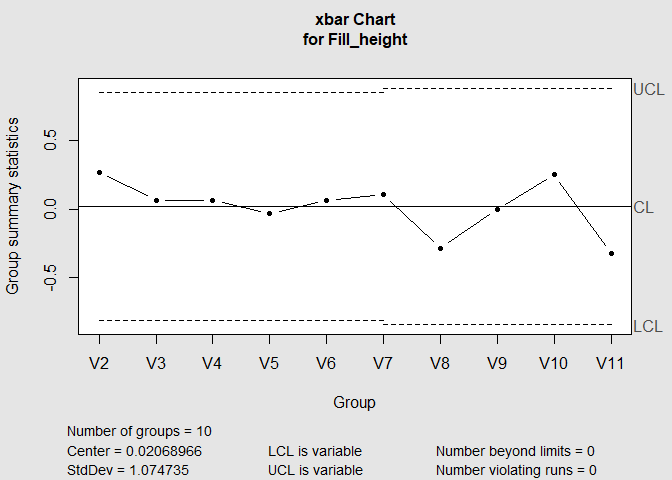

```
## List of 11
##  $ call      : language qcc(data = Fill_height, type = "xbar")
##  $ type      : chr "xbar"
##  $ data.name : chr "Fill_height"
##  $ data      : num [1:10, 1:15] 2.5 0.5 2 -1 1 -1 0.5 1.5 0.5 -1.5 ...
##   ..- attr(*, "dimnames")=List of 2
##  $ statistics: Named num [1:10] 0.2667 0.0667 0.0667 -0.0333 0.0667 ...
##   ..- attr(*, "names")= chr [1:10] "V2" "V3" "V4" "V5" ...
##  $ sizes     : Named int [1:10] 15 15 15 15 15 14 14 14 14 14
##   ..- attr(*, "names")= chr [1:10] "V2" "V3" "V4" "V5" ...
##  $ center    : num 0.0207
##  $ std.dev   : num 1.07
##  $ nsigmas   : num 3
##  $ limits    : num [1:10, 1:2] -0.812 -0.812 -0.812 -0.812 -0.812 ...
##   ..- attr(*, "dimnames")=List of 2
##  $ violations:List of 2
##  - attr(*, "class")= chr "qcc"
```

```r
#c
#removing the last 5 rows in the 15th column by setting them to NA
Fill_height[6:10, 15] <- NA
qcc(data = Fill_height, type = "xbar")
```

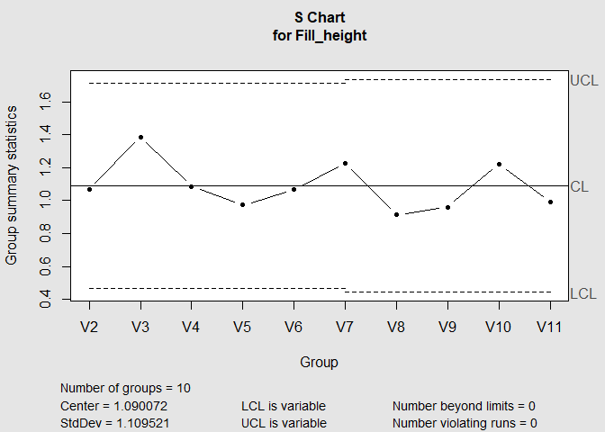

```
## List of 11
##  $ call      : language qcc(data = Fill_height, type = "S")
##  $ type      : chr "S"
##  $ data.name : chr "Fill_height"
##  $ data      : num [1:10, 1:15] 2.5 0.5 2 -1 1 -1 0.5 1.5 0.5 -1.5 ...
##   ..- attr(*, "dimnames")=List of 2
##  $ statistics: Named num [1:10] 1.067 1.387 1.083 0.972 1.067 ...
##   ..- attr(*, "names")= chr [1:10] "V2" "V3" "V4" "V5" ...
##  $ sizes     : Named int [1:10] 15 15 15 15 15 14 14 14 14 14
##   ..- attr(*, "names")= chr [1:10] "V2" "V3" "V4" "V5" ...
##  $ center    : num 1.09
##  $ std.dev   : num 1.11
##  $ nsigmas   : num 3
##  $ limits    : num [1:10, 1:2] 0.467 0.467 0.467 0.467 0.467 ...
##   ..- attr(*, "dimnames")=List of 2
##  $ violations:List of 2
##  - attr(*, "class")= chr "qcc"
```

```r
qcc(data = Fill_height, type = "S")
```

## Book Problem 6.9: Piston Ring

Consider the piston ring data shown in Table 6.3. Set up x and R control charts on this process. Is the process in statistical control?

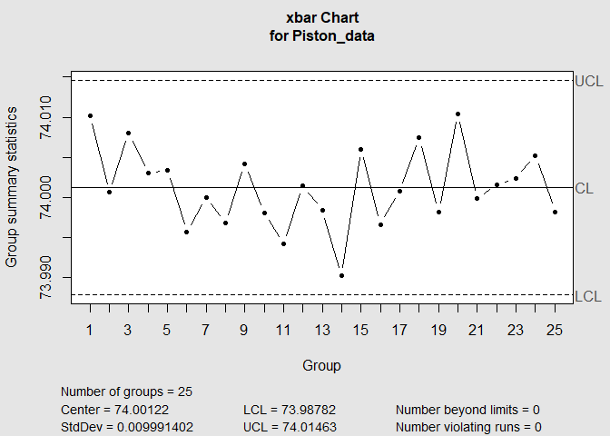

```
## List of 11
##  $ call      : language qcc(data = Piston_data, type = "xbar")
##  $ type      : chr "xbar"
##  $ data.name : chr "Piston_data"
##  $ data      : num [1:25, 1:5] 74 74 74 74 74 ...
##   ..- attr(*, "dimnames")=List of 2
##  $ statistics: Named num [1:25] 74 74 74 74 74 ...
##   ..- attr(*, "names")= chr [1:25] "1" "2" "3" "4" ...
##  $ sizes     : int [1:25] 5 5 5 5 5 5 5 5 5 5 ...
##  $ center    : num 74
##  $ std.dev   : num 0.00999
##  $ nsigmas   : num 3
##  $ limits    : num [1, 1:2] 74 74
##   ..- attr(*, "dimnames")=List of 2
##  $ violations:List of 2
##  - attr(*, "class")= chr "qcc"
```

```r
#enter data into R
Piston_data = data.frame(Observation1 = c(74.03, 73.995, 73.988, 74.002, 73.992,    74.009, 73.995, 73.985, 74.008, 73.998, 73.994, 74.004, 73.983, 74.006, 74.012, 74, 73.994, 74.006, 73.984, 74, 73.982, 74.004, 74.01,  74.015, 73.982), Observation2 = c(74.002,   73.992, 74.024, 73.996, 74.007, 73.994, 74.006, 74.003, 73.995, 74, 73.998, 74, 74.002, 73.967, 74.014, 73.984, 74.012, 74.01,  74.002, 74.01,  74.001, 73.999, 73.989, 74.008, 73.984), Observation3 = c(74.019,   74.001, 74.021, 73.993, 74.015, 73.997, 73.994, 73.993, 74.009, 73.99,  73.994, 74.007, 73.998, 73.994, 73.998, 74.005, 73.986, 74.018, 74.003, 74.013, 74.015, 73.99,  73.99,  73.993, 73.995), Observation4 = c(73.992,   74.011, 74.005, 74.015, 73.989, 73.985, 74, 74.015, 74.005, 74.007, 73.995, 74, 73.997, 74, 73.999, 73.998, 74.005, 74.003, 74.005, 74.02,  74.005, 74.006, 74.009, 74, 74.017), Observation5 = c(74.008,   74.004, 74.002, 74.009, 74.014, 73.993, 74.005, 73.988, 74.004, 73.995, 73.99,  73.996, 74.012, 73.984, 74.007, 73.996, 74.007, 74, 73.997, 74.009, 73.996, 74.009, 74.014, 74.01,  74.013))

#create graphs using the qcc function
qcc(data = Piston_data, type = "xbar")
```

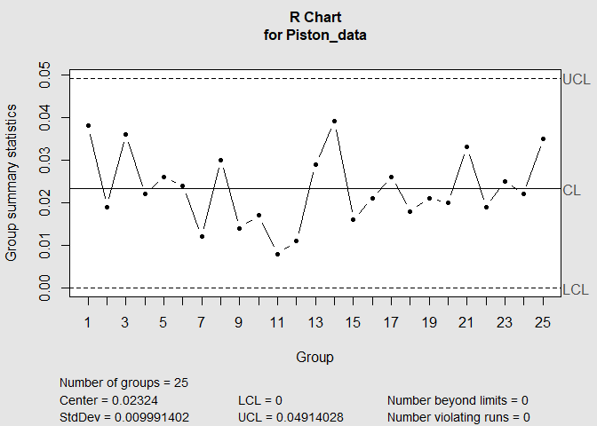

```
## List of 11
##  $ call      : language qcc(data = Piston_data, type = "R")
##  $ type      : chr "R"
##  $ data.name : chr "Piston_data"
##  $ data      : num [1:25, 1:5] 74 74 74 74 74 ...
##   ..- attr(*, "dimnames")=List of 2
##  $ statistics: Named num [1:25] 0.038 0.019 0.036 0.022 0.026 ...
##   ..- attr(*, "names")= chr [1:25] "1" "2" "3" "4" ...
##  $ sizes     : int [1:25] 5 5 5 5 5 5 5 5 5 5 ...
##  $ center    : num 0.0232
##  $ std.dev   : num 0.00999
##  $ nsigmas   : num 3
##  $ limits    : num [1, 1:2] 0 0.0491
##   ..- attr(*, "dimnames")=List of 2
##  $ violations:List of 2
##  - attr(*, "class")= chr "qcc"
```

```r
qcc(data = Piston_data, type = "R")
```

## Book Problem 6.10: Piston Ring Cont

Table 6E.7 shows 15 additional samples for the piston ring process (Table 6.3), taken after the initial control charts were established. Plot these data on the x and R chart developed in Exercise 6.9. Is the process in control?

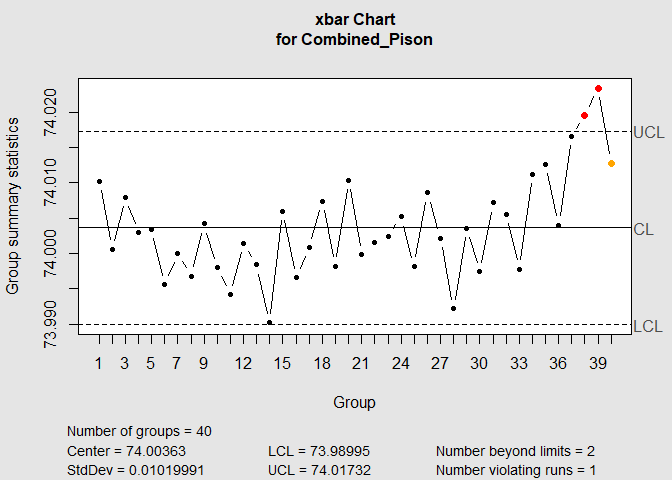

```
## List of 11
##  $ call      : language qcc(data = Combined_Pison, type = "xbar")
##  $ type      : chr "xbar"
##  $ data.name : chr "Combined_Pison"
##  $ data      : num [1:40, 1:5] 74 74 74 74 74 ...
##   ..- attr(*, "dimnames")=List of 2
##  $ statistics: Named num [1:40] 74 74 74 74 74 ...
##   ..- attr(*, "names")= chr [1:40] "1" "2" "3" "4" ...
##  $ sizes     : int [1:40] 5 5 5 5 5 5 5 5 5 5 ...
##  $ center    : num 74
##  $ std.dev   : num 0.0102
##  $ nsigmas   : num 3
##  $ limits    : num [1, 1:2] 74 74
##   ..- attr(*, "dimnames")=List of 2
##  $ violations:List of 2
##  - attr(*, "class")= chr "qcc"
```

```r
#read in new data (again, see the tutorial for how to get data from the textbook into R)
New_Piston_data <- read.csv("Piston_data_new.csv")
colnames(New_Piston_data) <- colnames(Piston_data) #make the column names match each other
Combined_Pison <- rbind(Piston_data, New_Piston_data) #rbind combines the rows of the two dataframes using the column names

qcc(data = Combined_Pison, type = "xbar")
```

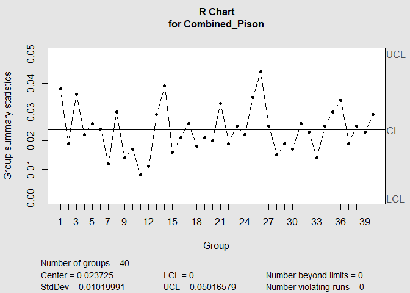

```
## List of 11
##  $ call      : language qcc(data = Combined_Pison, type = "R")
##  $ type      : chr "R"
##  $ data.name : chr "Combined_Pison"
##  $ data      : num [1:40, 1:5] 74 74 74 74 74 ...
##   ..- attr(*, "dimnames")=List of 2
##  $ statistics: Named num [1:40] 0.038 0.019 0.036 0.022 0.026 ...
##   ..- attr(*, "names")= chr [1:40] "1" "2" "3" "4" ...
##  $ sizes     : int [1:40] 5 5 5 5 5 5 5 5 5 5 ...
##  $ center    : num 0.0237
##  $ std.dev   : num 0.0102
##  $ nsigmas   : num 3
##  $ limits    : num [1, 1:2] 0 0.0502
##   ..- attr(*, "dimnames")=List of 2
##  $ violations:List of 2
##  - attr(*, "class")= chr "qcc"
```

```r
qcc(data = Combined_Pison, type = "R")
```

## Book Problem 6.56: Polymer Viscosity

Continuation of Exercise 6.55. The next five measurements on viscosity are 3163, 3199, 3054, 3147, and 3156. Do these measurements indicate that the process is in statistical control?

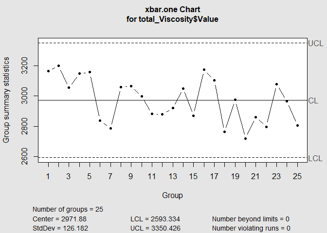

```
## List of 11
##  $ call      : language qcc(data = total_Viscosity$Value, type = "xbar.one")
##  $ type      : chr "xbar.one"
##  $ data.name : chr "total_Viscosity$Value"
##  $ data      : num [1:25, 1] 3163 3199 3054 3147 3156 ...
##   ..- attr(*, "dimnames")=List of 2
##  $ statistics: Named num [1:25] 3163 3199 3054 3147 3156 ...
##   ..- attr(*, "names")= chr [1:25] "1" "2" "3" "4" ...
##  $ sizes     : int [1:25] 1 1 1 1 1 1 1 1 1 1 ...
##  $ center    : num 2972
##  $ std.dev   : num 126
##  $ nsigmas   : num 3
##  $ limits    : num [1, 1:2] 2593 3350
##   ..- attr(*, "dimnames")=List of 2
##  $ violations:List of 2
##  - attr(*, "class")= chr "qcc"
```

```r
#read data into R
Viscosity_data <- read.csv("Polymer_Viscosity_data.csv")

#set column names
names(Viscosity_data) <- c("Sample", "Value")

#create a dataframe of the new data
new_Viscosity <- data.frame(Sample = 21:25, Value = c(3163, 3199, 3054, 3147, 3156))

#combine the two
total_Viscosity <- rbind(new_Viscosity, Viscosity_data)

#graph!
qcc(data = total_Viscosity$Value, type = "xbar.one")
```